# MSc in Molecular Biomedicine

Part IIa: Statistics, Similarity and Distance

Christoforos Nikolaou, Computational Genomics Group, BSRC ‘Alexander Fleming’

2020-11-09

## Introduction

- In this class we will be discussing problems of similarity that arise during general data analysis problems.
- In most of the cases these may be divided in two main types:
  1. Comparisons of distributions in order to assess general differences
  2. Comparisons of objects in order to create meaningful clustering/partitions
- We will study the above concepts using a hands-on approach through actual programming with the use of the R programming and data analysis environment

## Part A. An Introduction to R

### Using R for data analysis

We will use [R](https://www.r-project.org/about.html) in order to analyze data and perform a large number of statistical tests. R is basically a programming environment that allows the user to apply a lot of predefined functions without having to program him/herself.

In the following chapters we will include R code in the flow of the class content but I urge you to do some reading by yourselves from a number of interesting and useful resources, shown below:

- [An introduction to R](https://biocorecrg.github.io/CRG_RIntroduction/)
- [R in Codecademy](https://www.codecademy.com/learn/learn-r)

In the meanwhile I will try to help with additional material from my book (in Greek) whenever there is need.

The main focus though will be a hands-on approach, through which we will be discussing code for practical purposes and always with the aim of solving particular problems.

## Installing and using R

I strongly suggest that you install [R](https://www.r-project.org/) and [R-Studio](https://www.rstudio.com/) in order for you to use R and follow the material posted for the class. An alternative may be to use [R Studio over the cloud](https://rstudio.cloud/projects) by registering for free.

Once you have done this you may easily reproduce all the analyses we will be discussing in “class” and then modify and explore the code accordingly for your own work and assignments.

## Part A. Creating and Loading data in R

### Simple Variables

We will start by seeing how we create variables in R. Variables may either be singular values like:

```r
x<-5
```

We can see any variable by printing its name:

```r
x
```

```
## [1] 5
```

and we can use variables to pass values to other variables

```r
x<-5
y<-x # y now equals 5
y<-6 # y becomes 6
```

Variables can be real, decimal or complex numbers

```r
an_integer<-12
a_real<-3.141
a_complex<-5-8i
```

and they can also be character strings, which is quite useful for categorical data

```r
my_name<-'Christoforos'
my_passion<-"football"
a_character_variable<-"ytg67_a?"
```

last but not least, variables may also be logical values, (TRUE, FALSE or T, F) which we use **without** quotation

```r
my_logical1<-T
my_logical2<-FALSE
```

### Numerical processing

You can code for any numerical process in R using the corresponding symbol as shown in the table below

| Symbol | Process |
| --- | --- |
| + | Addition |
| - | Subtraction |
| * | Mutliplication |
| / | Division |
| ** | Power |
| %% | Modulo |

### Logical Processes

The logical processes we went through previously are also encoded in R

| Symbol | Control |
| --- | --- |
| == | Equal |
| != | Non-equal |
| > | Greater |
| < | Smaller |
| >= | Greater or equal |
| <= | Smaller or equal |

### Functions in R

Functions are R’s main characteristic. There is probably one for everything you would like to do and, if not, you can easily write your own, by combining pre-existing ones. The general syntax for R functions is:

> fun(variable(s), parameter(s))

where $fun()$ is the name of the function, which accepts variable(s) and parameter(s) inside parentheses.

## Variable Types in R

It is much more interesting to work with more complex variable types than singular values. R allows us to handle various data structures such as:

1. One dimensional **vectors**, which are ordered series of items of the same class (e.g. numbers). We create them with a simple function $c()$:

```r
vec<-c(1,2,5,3.14,8)
vec
```

```
## [1] 1.00 2.00 5.00 3.14 8.00
```

2. Two dimensional **matrices** which can only hold numerical values and are created with a function called $matrix()$. This needs a vector of values as input and a set of parameters to adjust the dimension of the matrix. In the following case we create a matrix containing the values from 1 to 20 (1:20) in a 4X5 matrix:

```r
matrix(1:20, nrow=4, ncol=5, byrow=T)
```

```
##      [,1] [,2] [,3] [,4] [,5]
## [1,]    1    2    3    4    5
## [2,]    6    7    8    9   10
## [3,]   11   12   13   14   15
## [4,]   16   17   18   19   20
```

3. Two dimensional **data frames** are versatile 2D tables that can hold multiple types of data (e.g. numerical, character and logical values), on the condition that each column has only one type. We create data frames as collections of vectors of the same size, with the function of the same name $data.frame()$:

```r
name<-c("Curtis", "James", "Joe", "Andrew", "Alex", "Kostas")
number<-c(17, 7, 12, 26, 15, 21)
starting<-c(F, F, T, T, F, F)
data.frame(name, number, starting)
```

```
##     name number starting
## 1 Curtis     17    FALSE
## 2  James      7    FALSE
## 3    Joe     12     TRUE
## 4 Andrew     26     TRUE
## 5   Alex     15    FALSE
## 6 Kostas     21    FALSE
```

4. Other types of data include tables and lists (but we will leave them for later)

### Data Input/Output in R

It is obviously much more practical to have the data loaded into R instead of typing them by hand. This can be done with a number of functions that belong to the same $read()$ family as shown in the table below:

| Name.of.Function | Performed.Action |
| --- | --- |
| read.table() | Reading of a 2D table |
| read.csv() | Reading of a comma-separated table |
| read.delim() | Reading of a table with a given delimiter |
| readLines() | Reading of text by line |

As an example, this is how we can load a file into R and store it as a data frame

```r
geneexp<-read.delim("GeneExpressionData.tsv", header=T, sep="\t")
```

and this is a nice way to go through the contents of the original file (called “GeneExpressionData.tsv”)

```r
str(geneexp)
```

```
## 'data.frame':    22427 obs. of  14 variables:
##  $ chromosome: Factor w/ 26 levels "chr1","chr1_random",..: 1 1 1 1 1 1 1 1 1 1 ...
##  $ TSS       : int  3204562 4280926 4481008 4763278 4797973 4847774 4899656 5073253 5578573 5903787 ...
##  $ TES       : int  3661579 4399322 4486494 4775807 4836816 4887990 5060366 5152630 5596214 5907479 ...
##  $ Gene      : Factor w/ 22427 levels "0610005C13Rik",..: 21737 17210 18816 12626 11413 19613 16958 2970 14899 13448 ...
##  $ h1logFC   : num  -0.9087 2.8525 0.5557 0.1441 0.0422 ...
##  $ h1pval    : num  1 1 1 0.715 0.908 ...
##  $ h3logFC   : num  -0.817 0 1.414 -0.158 -0.183 ...
##  $ h3pval    : num  1 1 1 0.681 0.578 ...
##  $ h6logFC   : num  -0.916 0 2.976 0.291 -0.107 ...
##  $ h6pval    : num  1 1 1 0.446 0.738 ...
##  $ h24logFC  : num  -0.6841 0.2022 0.7694 0.0187 -0.2093 ...
##  $ h24pval   : num  1 1 1 0.957 0.493 ...
##  $ d7logFC   : num  -0.691 0 -0.598 0.114 -0.554 ...
##  $ d7pval    : num  1 1 1 0.796 0.147 ...
```

We will come back to this file later on.

For now, let’s turn to some basic **statistical concepts** that will help us deal with the problems of comparisons

## Part B. Basic statistical concepts

### Sample and Population

Let’s start by examining the notions of **sample** and **population**. In statistics the *population* is the entire group that you are attempting to study. The *sample* is a subset of the population that you can actually analyze. What we want is to be able to draw conclusions about the former by looking into the latter. This is why it is very important that the sampling is representative, unbiased and sufficient.

One of the major problems with sampling is estimating central tendencies (mean, median etc) and spread (variance, standard deviation) for the population based on the group.

We will discuss this problem in greater detail while we get to practice R at the same time.

We will start by creating an ideal *population* of persons for which we will study their weight in kg. We will assume this to be a normally distributed population with a mean value of 75kb and a standard deviation of 15. In R it is easy to create sets of numbers with given means, variances for a large variety of distributions. Our population of 10000 members can be:

```r
weights<-rnorm(10000, mean=75, sd=15)
```

### Central Tendencies and Measures of Variation

We can check how well $rnorm()$ has simulated our distribution by calculating the mean and the standard deviation with $mean()$ and $sd()$:

```r
mean(weights)
```

```
## [1] 75.09021
```

```r
sd(weights)
```

```
## [1] 14.86755
```

(pretty well)

In the same way we did for mean and sd, we can calculate any set’s (numerical vector’s) median, variance, range or minimum and maximum values with a corresponding function:

```r
median(weights)
```

```
## [1] 75.06845
```

```r
var(weights)
```

```
## [1] 221.0442
```

```r
range(weights)
```

```
## [1]  24.2221 144.1125
```

```r
min(weights)
```

```
## [1] 24.2221
```

```r
max(weights)
```

```
## [1] 144.1125
```

### Random sampling

Remember that weights is our population and in practice we are unable to measure everyone of the 10000 individuals. We can only sample subsets of this group. We can simulated this sampling with a suitable function in R:

```r
s1<-sample(weights, 30, replace = F)
```

and accordingly we can calculate the sample’s mean and sd values:

```r
mean(s1)
```

```
## [1] 75.3508
```

```r
sd(s1)
```

```
## [1] 13.97652
```

Which is close but not exactly matching the ones of the population.

### Visualizing distributions as histograms

We can visualize this by graphically plotting the histograms of population and sample. Remember that in a histogram we plot the values of a given set organized in bins of certain size against their frequency in the set.

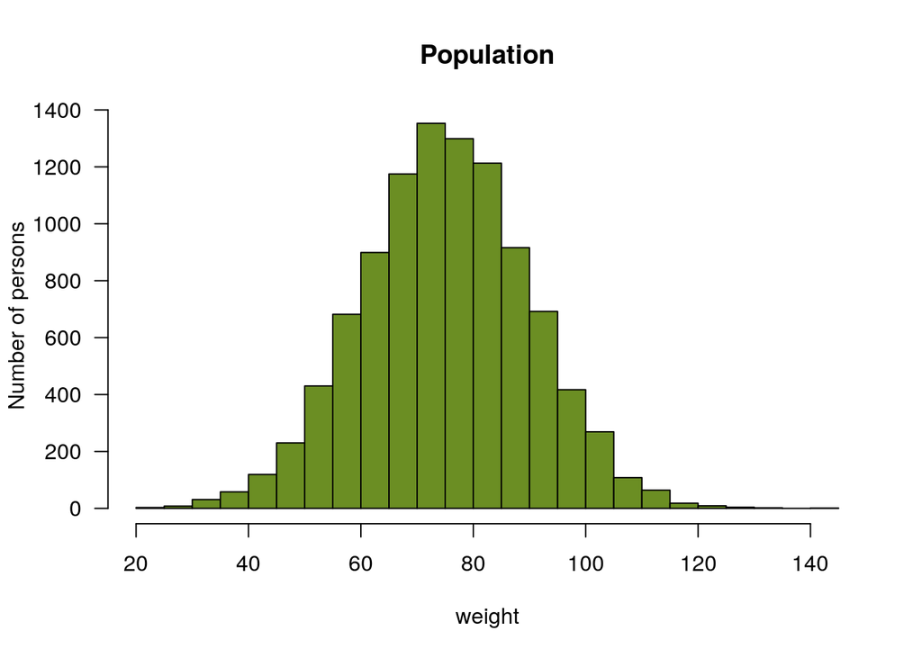

```r
hist(weights, breaks=30, las=1, main="Population", xlab="weight", col="olivedrab", freq = T, plot=T, ylab="Number of persons")
```

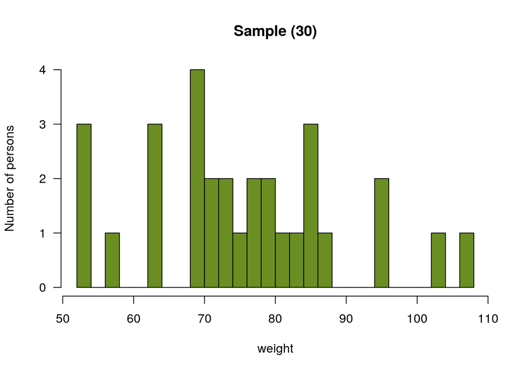

```r
hist(s1, breaks=30, las=1, main="Sample (30)", xlab="weight", col="olivedrab", freq = T, plot=T, ylab="Number of persons")
```

The differences are obvious and even more striking in the shape of the distributions. The structure of the population with a well defined mean=75 and most of the values within a range of mean+/-3*sd (this is a good approximation for the normal distribution)

When asking a statistician how many measurements/replicates to perform in an experiment, one thing you will often hear is “as many as possible”. You can see why as we go on to compare the histograms of samples of increasing size.

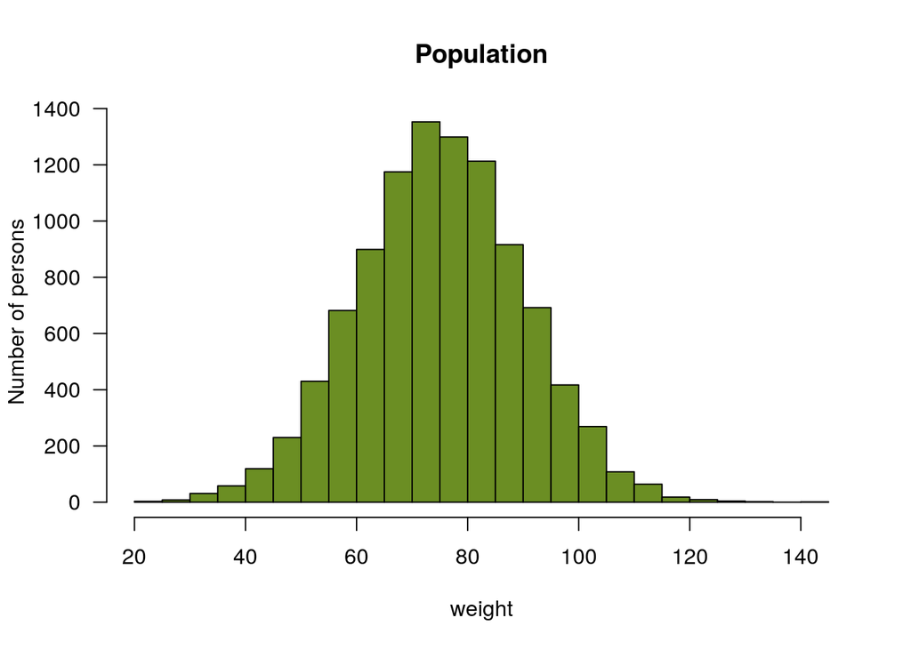

```r
hist(weights, breaks=30, las=1, main="Population", xlab="weight", col="olivedrab", freq = T, plot=T, ylab="Number of persons")
```

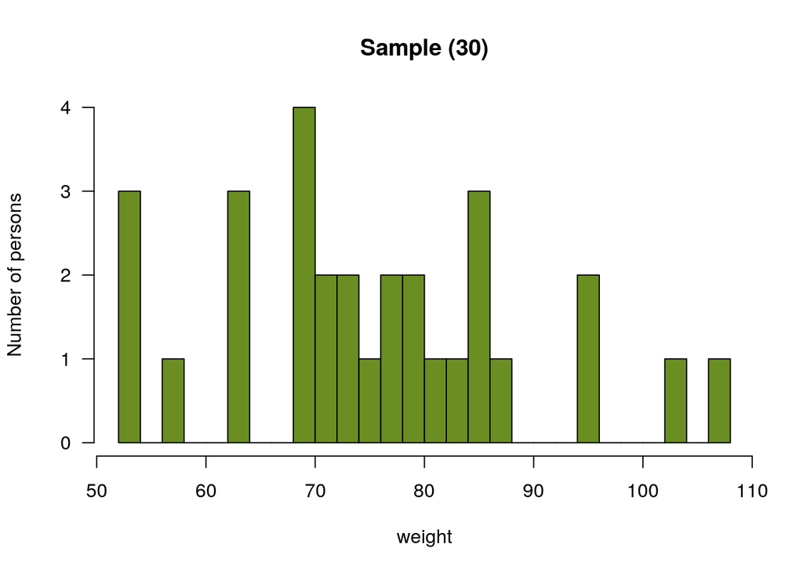

```r
hist(s1, breaks=30, las=1, main="Sample (30)", xlab="weight", col="olivedrab", freq = T, plot=T, ylab="Number of persons")
```

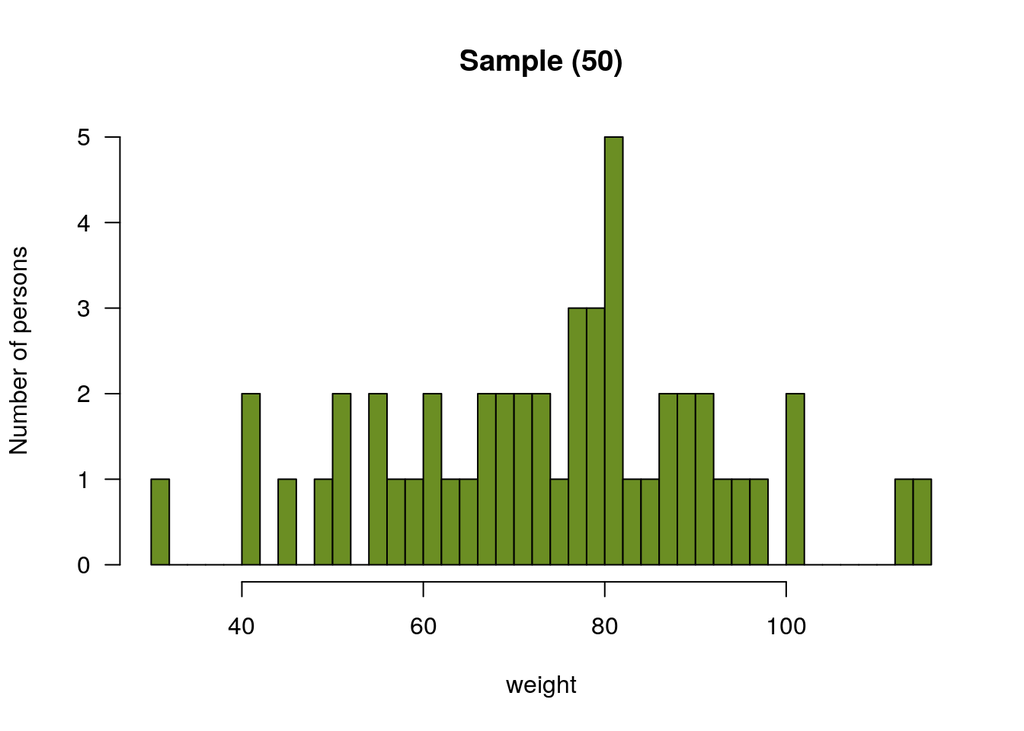

```r
s2<-sample(weights, 50, replace = F)
hist(s2, breaks=30, las=1, main="Sample (50)", xlab="weight", col="olivedrab", freq = T, plot=T, ylab="Number of persons")
```

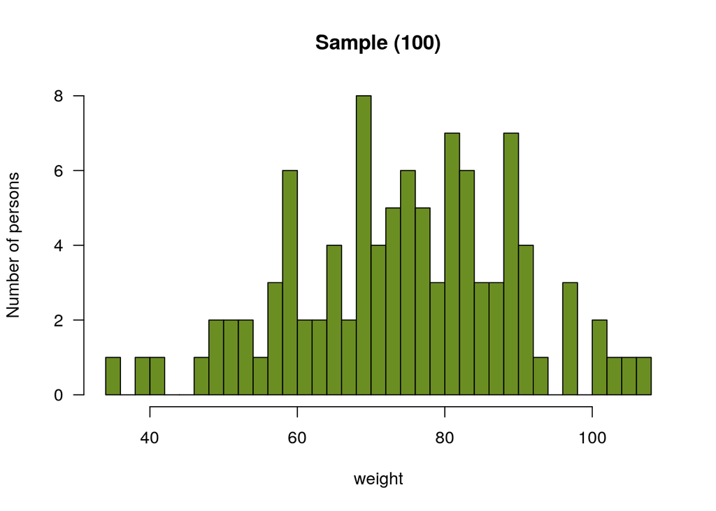

```r
s3<-sample(weights, 100, replace = F)
hist(s3, breaks=30, las=1, main="Sample (100)", xlab="weight", col="olivedrab", freq = T, plot=T, ylab="Number of persons")
```

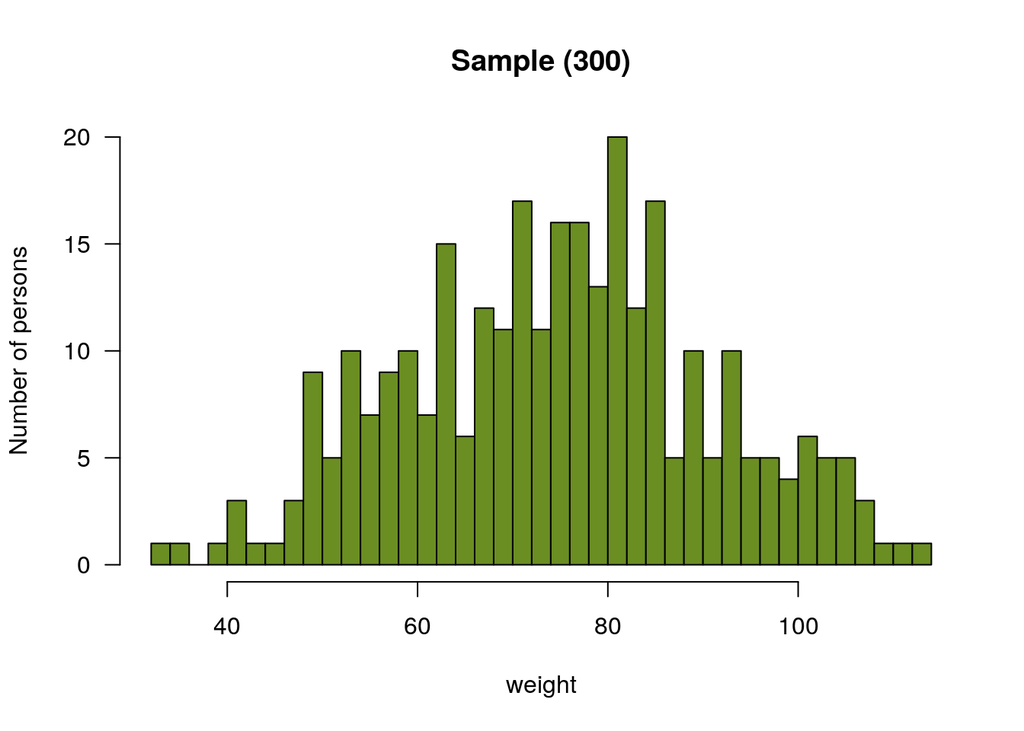

```r
s4<-sample(weights, 300, replace = F)
hist(s4, breaks=30, las=1, main="Sample (300)", xlab="weight", col="olivedrab", freq = T, plot=T, ylab="Number of persons")
```

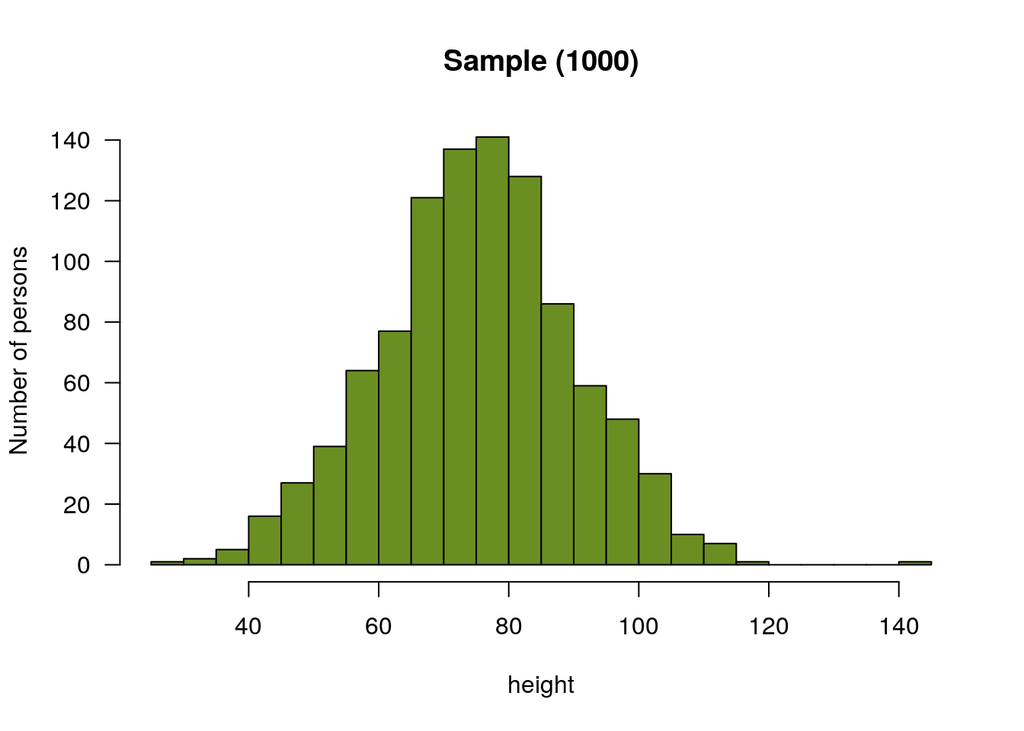

```r
s5<-sample(weights, 1000, replace = F)
hist(s5, breaks=30, las=1, main="Sample (1000)", xlab="height", col="olivedrab", freq = T, plot=T, ylab="Number of persons")
```

Compare the mean and sd of the last, more representative sample with the first, smaller one:

```r
mean(s5);
```

```
## [1] 75.22065
```

```r
sd(s5);
```

```
## [1] 14.89386
```

Which may help you see how better (in this case better=more) sampling helps you define the characteristics of the population more precisely.

```r
nrow(mtcars)
```

```
## [1] 32
```

Στην περίπτωση που θέλουμε να πάρουμε μια εικόνα για μια σύνθετη μεταβλητή χωρίς να την τυπώσουμε ολόκληρη μπορούμε να χρησιμοποιήσουμε συναρτήσεις που μας δίνουν ένα τμήμα των δεδομένων:

```r
head(mtcars)
```

```
##                    mpg cyl disp  hp drat    wt  qsec vs am gear carb
## Mazda RX4         21.0   6  160 110 3.90 2.620 16.46  0  1    4    4
## Mazda RX4 Wag     21.0   6  160 110 3.90 2.875 17.02  0  1    4    4
## Datsun 710        22.8   4  108  93 3.85 2.320 18.61  1  1    4    1
## Hornet 4 Drive    21.4   6  258 110 3.08 3.215 19.44  1  0    3    1
## Hornet Sportabout 18.7   8  360 175 3.15 3.440 17.02  0  0    3    2
## Valiant           18.1   6  225 105 2.76 3.460 20.22  1  0    3    1
```

H $head()$ επιστρέφει τις πρώτες γραμμές της μεταβλητής (με προεπιλεγμένη τιμή τις 6 γραμμές). Αντίστοιχα η $tail()$ επιστρέφει τις τελευταίες γραμμές. Αν κανείς θέλει να δει έναν συγκεκριμένο αριθμό γραμμών θα πρέπει να προσθέσει μια παράμετρο ακόμα στην εκτέλεση της συνάρτησης:

```r
head(mtcars, n=10)
```

```
##                    mpg cyl  disp  hp drat    wt  qsec vs am gear carb
## Mazda RX4         21.0   6 160.0 110 3.90 2.620 16.46  0  1    4    4
## Mazda RX4 Wag     21.0   6 160.0 110 3.90 2.875 17.02  0  1    4    4
## Datsun 710        22.8   4 108.0  93 3.85 2.320 18.61  1  1    4    1
## Hornet 4 Drive    21.4   6 258.0 110 3.08 3.215 19.44  1  0    3    1
## Hornet Sportabout 18.7   8 360.0 175 3.15 3.440 17.02  0  0    3    2
## Valiant           18.1   6 225.0 105 2.76 3.460 20.22  1  0    3    1
## Duster 360        14.3   8 360.0 245 3.21 3.570 15.84  0  0    3    4
## Merc 240D         24.4   4 146.7  62 3.69 3.190 20.00  1  0    4    2
## Merc 230          22.8   4 140.8  95 3.92 3.150 22.90  1  0    4    2
## Merc 280          19.2   6 167.6 123 3.92 3.440 18.30  1  0    4    4
```

Στη συγκεκριμένη εντολή βλέπουμε πώς μια συνάρτηση μπορεί να δεχτεί περισσότερες από μια παραμέτρους. Έτσι η $head()$ δέχεται ως πρώτο όρισμα το όνομα της μεταβλητής ενώ σε ένα δεύτερο όρισμα (που χωρίζεται από το πρώτο με κόμμα) δέχεται μια αριθμητική τιμή για την παράμετρο $n$ που είναι ο αριθμός των γραμμών που θέλουμε να επιστραφούν. Η εισαγωγή επιπλέον παραμέτρων είναι πολύ κοινή πρακτική για πολλές συναρτήσεις όπως θα δούμε πιο αναλυτικά σε επόμενα κεφάλαια.

Μια πιο αναλυτική εικόνα για μια οποιαδήποτε μεταβλητή μπορούμε να πάρουμε με τη συνάρτηση $str()$:

```r
str(mtcars)
```

```
## 'data.frame':    32 obs. of  11 variables:
##  $ mpg : num  21 21 22.8 21.4 18.7 18.1 14.3 24.4 22.8 19.2 ...
##  $ cyl : num  6 6 4 6 8 6 8 4 4 6 ...
##  $ disp: num  160 160 108 258 360 ...
##  $ hp  : num  110 110 93 110 175 105 245 62 95 123 ...
##  $ drat: num  3.9 3.9 3.85 3.08 3.15 2.76 3.21 3.69 3.92 3.92 ...
##  $ wt  : num  2.62 2.88 2.32 3.21 3.44 ...
##  $ qsec: num  16.5 17 18.6 19.4 17 ...
##  $ vs  : num  0 0 1 1 0 1 0 1 1 1 ...
##  $ am  : num  1 1 1 0 0 0 0 0 0 0 ...
##  $ gear: num  4 4 4 3 3 3 3 4 4 4 ...
##  $ carb: num  4 4 1 1 2 1 4 2 2 4 ...
```

Η $str()$ (που είναι συντομογραφία του structure) δίνει τη δομή της μεταβλητής με πολύ πιο αναλυτικό τρόπο από την $dim()$. Συγκεκριμένα δίνει αρχικά τον τύπο της μεταβλητης, ο οποίος είναι $data.frame$ δηλαδή πίνακας (περισσότερα για το συγκεκριμένο τύπο στο Κεφάλαιο 4) και οι διαστάσεις του είναι 32Χ11 (32 παρατηρήσεις για 11 μεταβλητές). Οι 11 “μεταβλητές” εδώ είναι οι παράμετροι για τις οποίες έχουμε μετρήσεις και οι οποίες δίνονται με τα ονόματά τους (mpg, cyl κλπ), καθώς και το είδος της κάθεμίας (εδώ όλες είναι numeric). Mπορούμε να πάρουμε τα ονόματα των συνιστωσών μεταβλητών του αντικειμένου mtcars με τη συνάρτηση $names()$:

```r
names(mtcars)
```

```
##  [1] "mpg"  "cyl"  "disp" "hp"   "drat" "wt"   "qsec" "vs"   "am"   "gear"
## [11] "carb"
```

Ένα παράδειγμα της $str()$ σε ένα άλλο προεγκατεστημένο σετ δεδομένων φαίνεται εδώ για το dataset $iris$:

```r
str(iris)
```

```
## 'data.frame':    150 obs. of  5 variables:
##  $ Sepal.Length: num  5.1 4.9 4.7 4.6 5 5.4 4.6 5 4.4 4.9 ...
##  $ Sepal.Width : num  3.5 3 3.2 3.1 3.6 3.9 3.4 3.4 2.9 3.1 ...
##  $ Petal.Length: num  1.4 1.4 1.3 1.5 1.4 1.7 1.4 1.5 1.4 1.5 ...
##  $ Petal.Width : num  0.2 0.2 0.2 0.2 0.2 0.4 0.3 0.2 0.2 0.1 ...
##  $ Species     : Factor w/ 3 levels "setosa","versicolor",..: 1 1 1 1 1 1 1 1 1 1 ...
```

Το οποίο βλέπουμε ότι είναι ένας 150Χ5 πίνακας με 4 αριθμητικές μεταβλητές (num) και μια μεταβλητή που ανήκει στο είδος factor, μια υποκατηγορία σειράς χαρακτήρων που θα δούμε στο επόμενο κεφάλαιο. Και από τα δύο παραδείγματα καταλαβαίνουμε ότι μια σύνθετη μεταβλητή μπορεί να αποτελείται από επιμέρους μεταβλητές με ξεχωριστά ονόματα. Στο επόμενο κεφάλαιο θα δούμε πώς μπορούμε να χειριστούμε τέτοια σύνθετα αντικείμενα.

## 2.5 Εισαγωγή Δεδομένων από αρχεία

Τα προεγκατεστημένα σύνολα δεδομένων είναι χρήσιμα για τη δοκιμή λειτουργιών και συναρτήσεων, ωστόσο ο σκοπός μας είναι να αναλύσουμε δεδομένα που έχουν προκύψει από δικά μας πειράματα και μετρήσεις. Προκειμένου να συμβεί αυτό θα πρέπει τα εξωτερικά αντικείμενα/αρχεία που περιέχουν τα αποτελέσματά μας να περάσουν στην R και να αποθηκευτούν σε μεταβλητές. Η R υποστηρίζει αυτή τη διαδικασία με μια σειρά από συναρτήσεις ανάγνωσης αρχείων, οι κυριότερες από τις οποίες φαίνονται στον Πίνακα 2.3:

Πίνακας 2.3: Κυριότερες Συναρτήσεις Ανάγνωσης

| Συνάρτηση | Λειτουργία |
| --- | --- |
| read.table() | Ανάγνωση Πίνακα |
| read.csv() | Ανάγνωση Πίνακα με διαχωριστή κόμμα |
| read.delim() | Ανάγνωση Πίνακα με δήλωση διαχωριστή |
| readLines() | Ανάγνωση κειμένου ανα γραμμή |

Οι τρεις πρώτες από τις παραπάνω συναρτήσεις δημιουργούν πίνακες του τύπου $data.frame$ όπως αυτός που είδαμε παραπάνω, ενώ η τελευταία δημιουργεί μια απλούστερη λίστα διαβάζοντας μία-μία τις γραμμές ενός αρχείου κειμένου.  
Πιο συγκεκριμένα η $read.table()$ είναι η γενική συνάρτηση ανάγνωσης δεδομένων σε πίνακα, η $read.csv()$ διαβάζει δεδομένα που είναι διαχωρισμένα σε στήλες με κόμμα μεταξύ τους (csv) και η $read.delim()$ επιτρέπει στον χρήστη να επιλέξει ο ίδιος τον διαχωριστή αρχείου που έχουν τα δεδομένα του. Ως διαχωριστές (delimiters) χρησιμοποιούνται συνήθως το κενό " “, το κόμμα”," ή το tab ". Η γενική σύνταξη των παραπάνω συναρτήσεων είναι η εξής

> readfunction(“nameoffile”, header=T/F, sep=“character”)

όπου:

1. Στο $nameoffile$ δίνεται το όνομα του αρχείου (μαζί με την κατάληξη) μέσα σε εισαγωγικά. Ανάλογα με τον φάκελο directory στο οποίο δουλεύουμε ενδέχεται να πρέπει να δώσουμε όχι μόνο το όνομα του αρχείου αλλά και το πλήρες μονοπάτι (full path) δηλαδή όλη τη διεύθυνση του αρχείου στον υπολογιστή που εργαζόμαστε (βλ. παρακάτω). Εναλλακτικά μπορούμε να αλλάξουμε τον φάκελο εργασίας με τη συνάρτηση $setwd()$ (βλ. Κεφάλαιο 1).
2. Στο $header=LOGICAL$ δίνεται μια λογική τιμή TRUE/FALSE ή πιο σύντομα T/F η οποία καθορίζει αν η πρώτη γραμμή του αρχείου θα χρησιμοποιηθεί ως επικεφαλίδα ή όχι.
3. Στο $sep="character"$ δίνεται ως τιμή ένας χαρακτήρας (ή μια σειρά χαρακτήρων) που θα χρησιμοποιηθεί ως διαχωριστής. Αν π.χ. το αρχείο που θέλουμε να διαβάσουμε είναι tsv (tab separated values) τότε η παράμετρος θα είναι $sep="\t"$.

### 2.5.3 Ορισμός φακέλου εργασίας και πλήρους μονοπατιού

Στα παραδείγματα που είδαμε παραπάνω τα αρχεία που διαβάσαμε βρίσκονται στο φάκελο εργασίας, δηλαδή τον φάκελο στον οποίο έχουμε ανοίξει την R. Όπως είδαμε στο προηγούμενο κεφάλαιο, για να δούμε ποιος είναι ο φάκελος εργασίας εκτελούμε την:

```r
getwd()
```

```
## [1] "/home/christoforos/Dropbox/Teaching/My_MScClasses/MBioMed/Class2020/RMarkdown"
```

Σε κάθε περίπτωση είναι καλό να έχουμε τον έλεγχο του φακέλου στον οποίο δουλεύουμε και να κρατάμε διαχωρισμένα τα αρχεία εισόδου/εξόδου.

## Συμπεράσματα

Στο πρώτο αυτό Κεφάλαιο σχετικά με τη χρήση της R είδαμε πώς μπορούμε να ενσωματώσουμε δεδομένα, να εξετάσουμε τη δομή τους και να κάνουμε απλές πράξεις και λογικούς ελέγχους σε αυτά. Ωστόσο τα είδη των δεδομένων ποικίλουν όχι μόνο ως προς τον τύπο αλλά και την πολυπλοκότητα. Στο επόμενο Κεφάλαιο θα δούμε τους τύπους των δεδομένων στην R και θα εξετάσουμε κάποιες από τις πιο βασικές συναρτήσεις για το χειρισμό τους.